# Somerville Rental Data

# Walksheds

```r
# Shapefiles from GIS

wkshds10<-st_read("Polygons.shp")%>%
  filter(ToBreak == 10,
         Name != "Relocated Lechmere Station : 0 - 10")%>%
  subset(select = c(Name, geometry))%>%
  mutate(glx10 = TRUE)

wkshds20<-st_read("Polygons.shp")%>%
  filter(ToBreak == 20,
         Name != "Relocated Lechmere Station : 10 - 20")%>%
  subset(select = c(Name, geometry))%>%
  mutate(glx20 = TRUE)

exsys_ws10<-st_read("Existing System 10 Min Walkshed.shp")%>%
   filter(ToBreak == 10)%>%
  subset(select = geometry)%>%
  mutate(exsys10 = TRUE)

exsys_ws20<-st_read("Existing System 10 Min Walkshed.shp")%>%
   filter(ToBreak == 20)%>%
  subset(select = geometry)%>%
  mutate(exsys20 = TRUE)
```

Things to do: pct millenial? pct elderly?

# Census

```r
#Census Tract Lines
v19 <- load_variables(2019, "acs5", cache = FALSE)%>%
  separate(label, into = paste0("label", 1:9), sep = "!!", fill = "right", remove = FALSE)


acs19_geom <- get_acs(state = "MA", county = "Middlesex", geography = "tract", year = 2019,
                  variable = "B01001_001", geometry = TRUE)%>%
              subset(select = -c(variable, estimate))


acs19_geombg <- get_acs(state = "MA", county = c("Middlesex"), year = 2019,
                        geography = "block group",variable = "B01001_001",
                        geometry = TRUE)%>%
              subset(select = -c(variable, estimate))

middlesex<-  get_acs(state = "MA", county = "Middlesex", geography = "county",
                  variable = "B01001_001", geometry = TRUE)%>%
              subset(select = -c(variable, estimate))%>%
  st_transform(MA_state_plane)
```

## Loading Census Data for Middlesex County

```r
# Variables

lm_vars<- c("B25004_001", "B25004_002","B25007_012", "B09020_006", "B11001_002", "B15011_002", "B25002_001","B01001_001","B19013_001")


###
#Calls
###

# Linear Model
lm_bg19<- get_acs(state = "MA", county = c("Middlesex"),
                  geography = "block group", year = 2019, variables = lm_vars)%>%
          mutate(variable = case_when(variable=="B25004_001"~ "totvac",
                                      variable=="B25004_002"~ "rentvac",
                                      variable=="B25007_012"~ "totrent",
                                      variable=="B09020_006"~ "femhh",
                                      variable=="B11001_002"~ "totfam",
                                      variable=="B15011_002"~ "totba",
                                      variable=="B25002_001"~ "tothh",
                                      variable=="B01001_001"~ "totpop",
                                      variable=="B19013_001" ~ "medinc"))%>%
   subset(select = -moe)%>%
        pivot_wider(names_from = "variable",
                    values_from = "estimate")%>%
  mutate(pctvac = totvac/tothh,
         pctrvac = rentvac/tothh,
         pctrent = totrent/tothh,
         pctfemhh= femhh/tothh,
         pctfam = totfam/tothh,
         pctba =  totba/totpop
         )

full_data2 <- inner_join(lm_bg19, acs19_geombg, by = "GEOID")%>%
  subset(select = -c(NAME.x, NAME.y, moe))

lm_dataset <-st_as_sf(full_data2,crs= lat_lon_CRS)%>%
  st_transform(MA_state_plane)
#EJ for Somerville

som_ej<-st_read("middlesex-ej.shp")
```

# Linear Model to Predict Displacement Risks

Equation from 2014 MAPC Report “Dimensions of Displacment”

rent/br = a0 + a1Station + a2Walkshed+ a3(Station*Walkshed)+ a4[medinc] +a5[pctvac]+ a6[pctrent] + a7 [pctfam] +a8[pctba]

## Calculating Apartments with GLX and Existing System Walkshed and Stations

note: this calculated the nearest station for every apartment in the dataset. I’m not sure if this makes sense to do but it seems to be what MAPC did. My final set is just Middlesex county, within a mile of transit at so it might not be that bad.

```r
###
#nearest GLX station
###

gb_apt_sf<- gb_apt_sf[middlesex,]

idk<-st_nn(gb_apt_sf,glx)
ns<- as.numeric(idk)

gb_apt_sf<-gb_apt_sf%>%
  mutate(near_station = glx$Name[ns])

#gb_apt_sf$near_station[is.na(gb_apt_sf$near_station)] = "Average"

unique(gb_apt_sf$near_station)
```

```
## [1] "Union Square Station"      "Magoun Square Station"
## [3] "Ball Square Station"       "College Ave Station"
## [5] "Gilman Square Station\n"   "East Somerville Station\n"
```

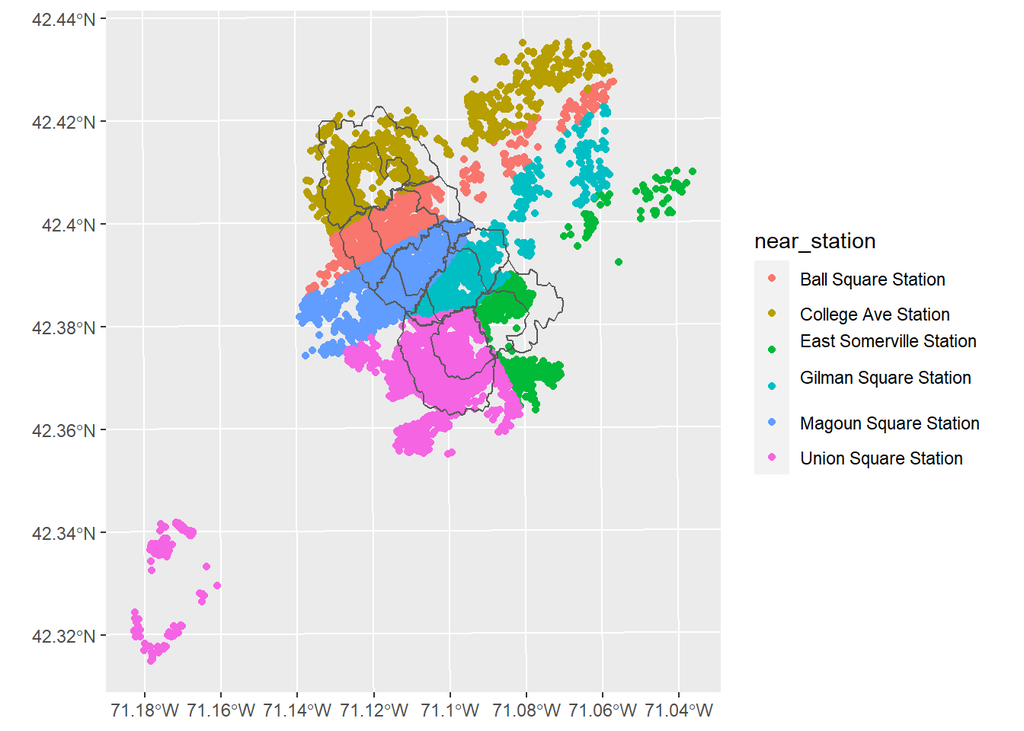

```r
ggplot(gb_apt_sf) +
  geom_sf(aes(color = near_station))+
  geom_sf(data = wkshds10, fill = NA)+
  geom_sf(data = wkshds20, fill = NA)
```

## Point In Point Walksheds

```r
###
#10 Min GLX Walksheds
###

gb_apts<- as(gb_apt_sf, "Spatial")
gb_apts<- gb_apts%>%spTransform("+proj=longlat +datum=WGS84 +no_defs +ellps=WGS84 +towgs84=0,0,0")

#proj4string(gb_apts) <- CRS("+proj=longlat +datum=WGS84")

wkshds10_sp<-as(wkshds10, "Spatial")
wkshds10_sp<-wkshds10_sp%>%spTransform("+proj=longlat +datum=WGS84 +no_defs +ellps=WGS84 +towgs84=0,0,0")

wkshds10_sp@proj4string
proj4string(gb_apts) <- proj4string(wkshds10_sp)
wkshdspip <- point.in.poly(gb_apts,wkshds10_sp)

#head(wkshdspip@data)

lm_aptdf<- wkshdspip

#head(lm_aptdf@data)


###
#20 Min GLX Walkshed Indicator
###
wkshds20_sp<-as(wkshds20, "Spatial")
wkshds20_sp<-wkshds20_sp%>%spTransform("+proj=longlat +datum=WGS84 +no_defs +ellps=WGS84 +towgs84=0,0,0")

wkshds20_sp@proj4string
proj4string(lm_aptdf) <- proj4string(wkshds20_sp)
wkshds20pip <- point.in.poly(lm_aptdf,wkshds20_sp)



lm_aptdf<- wkshds20pip

#head(lm_aptdf@data)


###
#Existing System Walkshed Indicator 10 min
###

exsys10_sp<-as(exsys_ws10, "Spatial")
exsys10_sp<-exsys10_sp%>%spTransform("+proj=longlat +datum=WGS84 +no_defs +ellps=WGS84 +towgs84=0,0,0")

exsys10_sp@proj4string
proj4string(lm_aptdf) <- proj4string(exsys10_sp)
exsys10pip <- point.in.poly(lm_aptdf,exsys10_sp)



lm_aptdf<- exsys10pip


###
#Existing System Walkshed Indicator 20 min
###

exsys20_sp<-as(exsys_ws20, "Spatial")
exsys20_sp<-exsys20_sp%>%spTransform("+proj=longlat +datum=WGS84 +no_defs +ellps=WGS84 +towgs84=0,0,0")

exsys20_sp@proj4string
proj4string(lm_aptdf) <- proj4string(exsys20_sp)
exsys20pip <- point.in.poly(lm_aptdf,exsys20_sp)



lm_aptdf<- exsys20pip

#head(lm_aptdf@data)
```

## Assigning census block group data to apt point

Sources for the code written here:

Spatial Object Transformations: https://datawanderings.com/2018/09/01/r-point-in-polygon-a-mathematical-cookie-cutter/

More Functions: https://gis.stackexchange.com/questions/287846/extract-data-of-polygon-shape-which-intersect-with-point-shape-r-and-create-data

https://gis.stackexchange.com/questions/137621/join-spatial-point-data-to-polygons-in-r?noredirect=1&lq=1

```r
#point data from lm_aptdf above, already spatial

#Spatial Object Transformations: sf to sp
#coordinates(lm_aptdf)<-c("long", "lat") #returns "Large SpatialPointsDataFrame"
#Assinging a CRS to points
#proj4string(lm_aptdf) <- CRS("+proj=longlat +datum=WGS84")

#coerces sf polygons to Large SpatialPolygonsDataFrame
lm_dataset<-as(lm_dataset, "Spatial")
#Assings the CRS Projection
lm_dataset<-lm_dataset%>%spTransform("+proj=longlat +datum=WGS84 +no_defs +ellps=WGS84 +towgs84=0,0,0")
#Check CRS is WGS84
lm_dataset@proj4string
#Makes sure R knows both objects have the same CRS
proj4string(lm_aptdf) <- proj4string(lm_dataset)
#What we initially set out to do
pointsinpoly <- point.in.poly(lm_aptdf,lm_dataset)


lm_aptdf<-pointsinpoly

###
##EJ
###

som_ejSP<-as(som_ej, "Spatial")
#Assings the CRS Projection
som_ejSP<-som_ejSP%>%spTransform("+proj=longlat +datum=WGS84 +no_defs +ellps=WGS84 +towgs84=0,0,0")
#Check CRS is WGS84
som_ejSP@proj4string
#Makes sure R knows both objects have the same CRS
proj4string(lm_aptdf) <- proj4string(som_ejSP)
#What we initially set out to do
ejpip <- point.in.poly(lm_aptdf,som_ejSP)


lm_aptdf<-ejpip

#for data changes
lm_final <-lm_aptdf@data

lm_final$BR_adj<- replace(lm_final$BR, lm_final$BR==0, 1)

lm_final<- lm_final%>%
  filter(!is.na(totpop))%>%
  mutate(PPBR = PRICE/BR_adj,
        in_glx = ifelse(is.na(glx10), 0, 1),
        in_glx20 = ifelse(is.na(glx20), 0, 1),
        exsys = if_else(is.na(exsys10), 0, 1),
        exsys20 = if_else(is.na(exsys20), 0, 1)) %>%
  subset(select = -c(GEOID.y, GEOID.x, moe))

lm_final<- rename(lm_final, "station10" = "Name.x")
lm_final<- rename(lm_final, "station20" = "Name.y")


colnames(lm_final)


#write.csv(lm_final, "lmdata.csv")
```